# Asignacion3

Jesus Rincon

10 de abril de 2016

# Instalamos librerias necesarias

```r
library(plot3D)
```

# Jambu

Declaramos una funcion a usar, en la cual se ploteara el codo de Jambu

```r
jambu <- function(data, nc=15, seed=1234){
  wss <- (nrow(data)-1)*sum(apply(data,2,var))
  for (i in 2:nc){
    set.seed(seed)
    wss[i] <- sum(kmeans(data, centers=i)$withinss)}
  plot(1:nc, wss, type="b", xlab="Numero de Clusters",
       ylab="Dentro de los grupos")}
```

# a.csv

Cargamos los datos.

```r
a <- read.csv("a.csv", header = FALSE)
a <- as.data.frame(a)
a.plot <- subset(a, select = -c(V3))
```

Visualizamos el codo de Jambu asociado al dataset

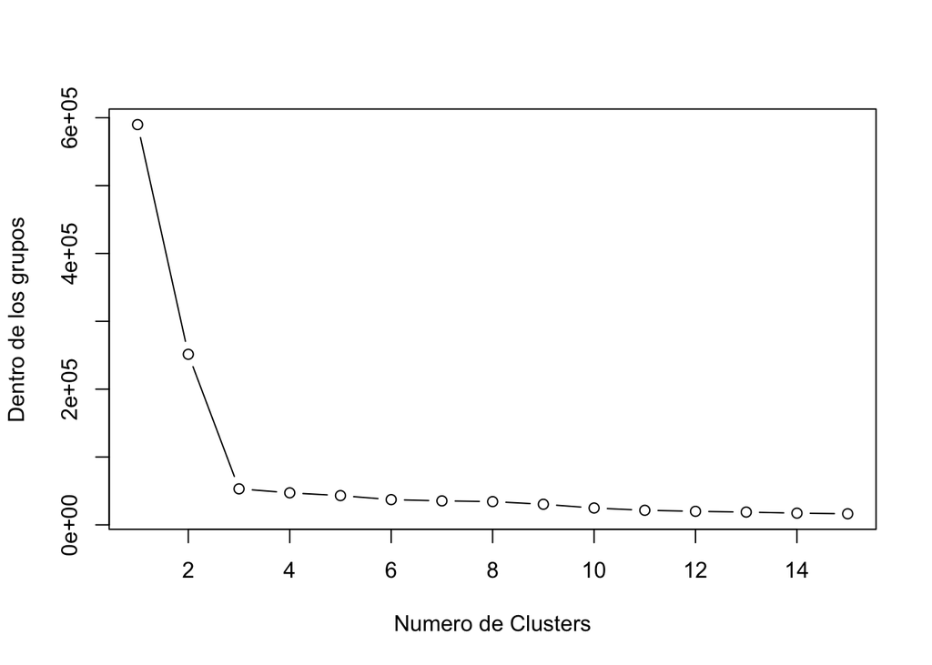

```r
jambu(a)
```

##Kmeans en a.csv

Como se obserba segun el Codo de Jambu se procede a ejecutar los codigos sabiendo que el optimo numero de clusters es 3 dado a que de ahi en adelante deja de ser tan pronunciada la recta entre puntos de la curva

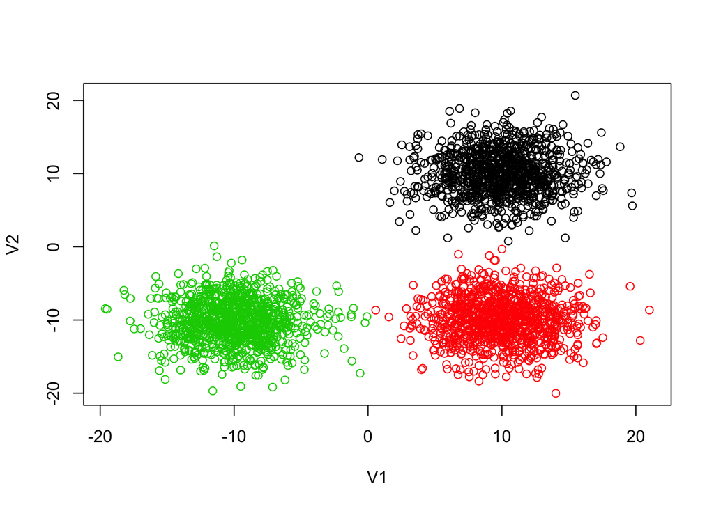

```r
a.kmeans <- kmeans(a.plot, centers = 3)
plot(a.plot, col = a.kmeans$cluster)
```

###Matriz de confusion en Kmeans de a.csv

```r
MCk <- table(true = a$V3, pred = a.kmeans$cluster)
MCk
```

```
##     pred
## true    1    2    3
##    0 1000    0    0
##    1    0    0 1000
##    2    1  999    0
```

### Matriz de confusion con cluster y metodo Single

```r
a.single <- hclust(dist(as.matrix(a.plot)), method = "single")
cortes.single <- cutree(a.single, k = 3)
MCs <- table(true = a$V3, pred = cortes.single)
MCs
```

```
##     pred
## true    1    2    3
##    0  999    1    0
##    1 1000    0    0
##    2  999    0    1
```

### Matriz de confusion con cluster y metodo Complete

```r
a.complete <- hclust(dist(as.matrix(a.plot)), method = "complete")
cortes.complete <- cutree(a.complete, k = 3)
MCc <- table(true = a$V3, pred = cortes.complete)
MCc
```

```
##     pred
## true    1    2    3
##    0    0 1000    0
##    1 1000    0    0
##    2   47    6  947
```

### Matriz de confusion con cluster y metodo Average

```r
a.average <- hclust(dist(as.matrix(a.plot)), method = "average")
cortes.average <- cutree(a.average, k = 3)
MCa <- table(true = a$V3, pred = cortes.average)
MCa
```

```
##     pred
## true    1    2    3
##    0    0 1000    0
##    1 1000    0    0
##    2    2    6  992
```

# guess.csv

cargamos los datos

```r
guess <- read.csv("guess.csv", header = FALSE)
guess <- as.data.frame(guess)
```

Procedemos a ver el codo de jambu respectivo

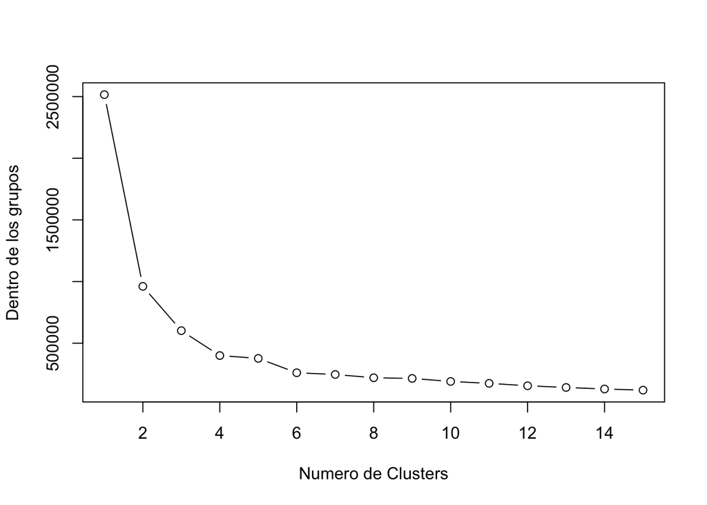

```r
jambu(guess)
```

#Kmeans en guess.csv

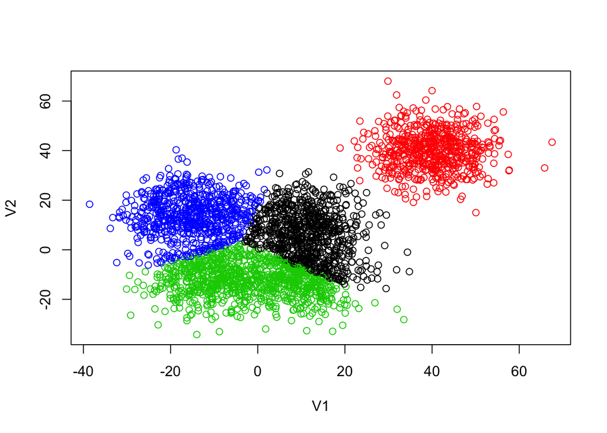

```r
guess.kmeans <- kmeans(guess, centers = 4)
plot(guess, col = guess.kmeans$cluster)
```

```r
guess.single <- hclust(dist(as.matrix(guess)), method = "single")
cortes.single <- cutree(guess.single, k = 4)
```

```r
guess.complete <- hclust(dist(as.matrix(guess)), method = "complete")
cortes.complete <- cutree(guess.complete, k = 4)
```

```r
guess.average <- hclust(dist(as.matrix(guess)), method = "average")
cortes.complete <- cutree(guess.complete, k = 4)
```

# h.csv

procedemos a cargar los datos

```r
h <- read.csv("h.csv", header = FALSE)
h <- as.data.frame(h)
hclass <- as.data.frame(h$V4)
```

codo de Jambu

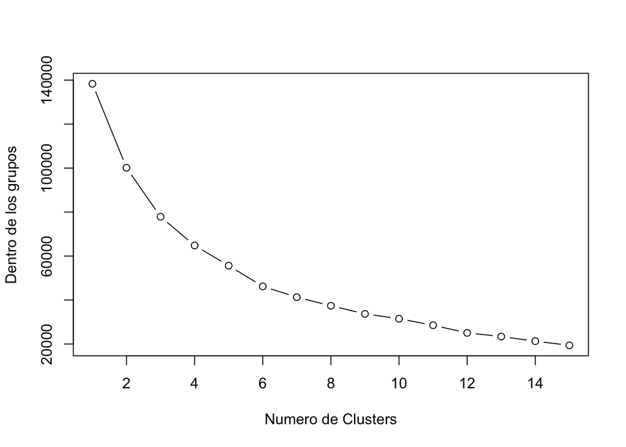

```r
jambu(h)
```

Como se observa, la curva comienza a dejar de ser pronunciada a partir del 4to cluster

Ahora bien, al observar el dataset vemos que la columna referente a la case, no son numeros enteros. sino valores asociados a rangos

```r
summary(hclass)
```

```
##       h$V4
##  Min.   : 4.718
##  1st Qu.: 7.046
##  Median : 9.249
##  Mean   : 9.386
##  3rd Qu.:11.661
##  Max.   :14.135
```

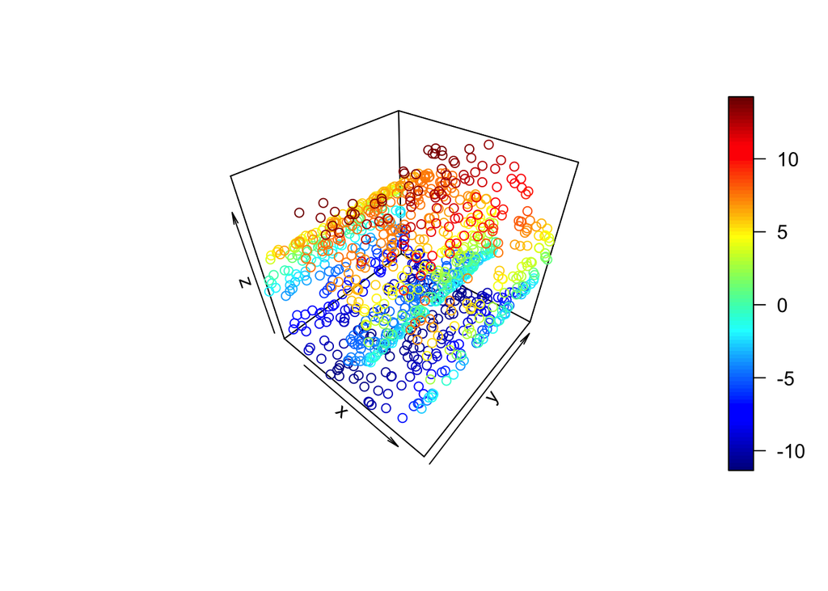

```r
#Hacemos regla para las clases
hclass[ hclass < 7.046] = 1
hclass[ hclass < 9.386 & hclass >= 7.046 ] = 2
hclass[ hclass < 11.661 & hclass >= 9.386 ] = 3
hclass[ hclass >= 11.661] = 4
points3D(x = h$V1, y = h$V2, z = h$V3)
```

## Kmeans en h.csv

```r
h.kmeans <- kmeans(h, centers = 4)
MCk <- table(true = h$V4, predict = h.kmeans$cluster)
MCk
```

```
##            predict
## true        1 2 3 4
##   4.717535  1 0 0 0
##   4.725427  0 1 0 0
##   4.737866  1 0 0 0
##   4.748772  1 0 0 0
##   4.756643  0 1 0 0
##   4.760955  1 0 0 0
##   4.786695  0 1 0 0
##   4.82009   0 1 0 0
##   4.822792  0 1 0 0
##   4.825828  1 0 0 0
##   4.827099  1 0 0 0
##   4.837143  1 0 0 0
##   4.859473  1 0 0 0
##   4.866281  0 1 0 0
##   4.867235  1 0 0 0
##   4.871401  1 0 0 0
##   4.886953  0 1 0 0
##   4.889479  0 1 0 0
##   4.892618  0 1 0 0
##   4.893281  0 1 0 0
##   4.901898  0 1 0 0
##   4.902943  1 0 0 0
##   4.90702   0 1 0 0
##   4.941535  1 0 0 0
##   4.944981  0 1 0 0
##   4.954254  1 0 0 0
##   4.98526   1 0 0 0
##   4.9875    1 0 0 0
##   4.994664  0 1 0 0
##   4.99735   0 1 0 0
##   5.012464  1 0 0 0
##   5.02411   0 1 0 0
##   5.026278  0 1 0 0
##   5.045672  1 0 0 0
##   5.052     0 1 0 0
##   5.075782  0 1 0 0
##   5.081725  1 0 0 0
##   5.085756  0 1 0 0
```

[output cut: 947 more lines]

```
##   13.965913 0 0 1 0
##   13.980963 0 0 1 0
##   14.000427 0 0 1 0
##   14.017932 0 0 1 0
##   14.027593 0 0 1 0
##   14.037356 0 0 1 0
##   14.046114 0 0 1 0
##   14.046171 0 0 1 0
##   14.060735 0 0 1 0
##   14.061875 0 0 1 0
##   14.084396 0 0 1 0
##   14.117962 0 0 1 0
##   14.1263   0 0 1 0
##   14.130362 0 0 1 0
##   14.135363 0 0 1 0
```

## cluster jerarquico en h.csv

### Metodo Single

```r
h.single <- hclust(dist(as.matrix(h)), method = "single")
corte.h.single <- cutree(h.single, k = 4)
MCs <- table( true = h$V4, predict = corte.h.single)
MCs
```

```
##            predict
## true        1 2 3 4
##   4.717535  1 0 0 0
##   4.725427  1 0 0 0
##   4.737866  1 0 0 0
##   4.748772  1 0 0 0
##   4.756643  1 0 0 0
##   4.760955  1 0 0 0
##   4.786695  1 0 0 0
##   4.82009   1 0 0 0
##   4.822792  1 0 0 0
##   4.825828  1 0 0 0
##   4.827099  1 0 0 0
##   4.837143  1 0 0 0
##   4.859473  1 0 0 0
##   4.866281  1 0 0 0
##   4.867235  1 0 0 0
##   4.871401  1 0 0 0
##   4.886953  1 0 0 0
##   4.889479  1 0 0 0
##   4.892618  1 0 0 0
##   4.893281  1 0 0 0
##   4.901898  1 0 0 0
##   4.902943  1 0 0 0
##   4.90702   1 0 0 0
##   4.941535  1 0 0 0
##   4.944981  1 0 0 0
##   4.954254  1 0 0 0
##   4.98526   1 0 0 0
##   4.9875    1 0 0 0
##   4.994664  1 0 0 0
##   4.99735   1 0 0 0
##   5.012464  1 0 0 0
##   5.02411   1 0 0 0
##   5.026278  1 0 0 0
##   5.045672  1 0 0 0
##   5.052     1 0 0 0
##   5.075782  1 0 0 0
##   5.081725  1 0 0 0
##   5.085756  1 0 0 0
```

[output cut: 947 more lines]

```
##   13.965913 1 0 0 0
##   13.980963 1 0 0 0
##   14.000427 1 0 0 0
##   14.017932 1 0 0 0
##   14.027593 1 0 0 0
##   14.037356 1 0 0 0
##   14.046114 1 0 0 0
##   14.046171 1 0 0 0
##   14.060735 1 0 0 0
##   14.061875 1 0 0 0
##   14.084396 1 0 0 0
##   14.117962 1 0 0 0
##   14.1263   1 0 0 0
##   14.130362 1 0 0 0
##   14.135363 1 0 0 0
```

### Metodo Complete

```r
h.complete <- hclust(dist(as.matrix(h)), method = "complete")
corte.h.complete <- cutree(h.complete, k = 4)
MCs <- table( true = h$V4, predict = corte.h.complete)
MCs
```

```
##            predict
## true        1 2 3 4
##   4.717535  0 0 0 1
##   4.725427  0 0 1 0
##   4.737866  0 0 0 1
##   4.748772  0 0 0 1
##   4.756643  0 0 0 1
##   4.760955  0 0 0 1
##   4.786695  0 0 1 0
##   4.82009   0 0 1 0
##   4.822792  0 0 0 1
##   4.825828  0 0 0 1
##   4.827099  0 0 0 1
##   4.837143  0 0 0 1
##   4.859473  0 0 0 1
##   4.866281  0 0 1 0
##   4.867235  0 0 0 1
##   4.871401  0 0 0 1
##   4.886953  0 0 0 1
##   4.889479  0 0 1 0
##   4.892618  0 0 0 1
##   4.893281  0 0 1 0
##   4.901898  0 0 1 0
##   4.902943  0 0 0 1
##   4.90702   0 0 0 1
##   4.941535  0 0 0 1
##   4.944981  0 0 0 1
##   4.954254  0 0 0 1
##   4.98526   0 0 0 1
##   4.9875    0 0 0 1
##   4.994664  0 0 1 0
##   4.99735   0 0 0 1
##   5.012464  0 0 0 1
##   5.02411   0 0 0 1
##   5.026278  0 0 1 0
##   5.045672  0 0 0 1
##   5.052     0 0 1 0
##   5.075782  0 0 1 0
##   5.081725  0 0 0 1
##   5.085756  0 0 0 1
```

[output cut: 947 more lines]

```
##   13.965913 0 1 0 0
##   13.980963 0 1 0 0
##   14.000427 0 0 1 0
##   14.017932 0 1 0 0
##   14.027593 0 1 0 0
##   14.037356 0 0 1 0
##   14.046114 0 1 0 0
##   14.046171 0 1 0 0
##   14.060735 0 0 1 0
##   14.061875 0 1 0 0
##   14.084396 0 0 1 0
##   14.117962 0 0 1 0
##   14.1263   0 0 1 0
##   14.130362 0 1 0 0
##   14.135363 0 1 0 0
```

### Metodo Average

```r
h.average <- hclust(dist(as.matrix(h)), method = "average")
corte.h.average <- cutree(h.average, k = 4)
MCs <- table( true = h$V4, predict = corte.h.average)
MCs
```

```
##            predict
## true        1 2 3 4
##   4.717535  0 1 0 0
##   4.725427  0 0 0 1
##   4.737866  0 1 0 0
##   4.748772  0 1 0 0
##   4.756643  0 1 0 0
##   4.760955  0 1 0 0
##   4.786695  0 0 0 1
##   4.82009   0 0 0 1
##   4.822792  0 1 0 0
##   4.825828  0 1 0 0
##   4.827099  0 1 0 0
##   4.837143  0 1 0 0
##   4.859473  0 1 0 0
##   4.866281  0 0 0 1
##   4.867235  0 1 0 0
##   4.871401  0 1 0 0
##   4.886953  0 1 0 0
##   4.889479  0 1 0 0
##   4.892618  0 1 0 0
##   4.893281  0 0 0 1
##   4.901898  0 0 0 1
##   4.902943  0 1 0 0
##   4.90702   0 1 0 0
##   4.941535  0 1 0 0
##   4.944981  0 1 0 0
##   4.954254  0 1 0 0
##   4.98526   0 1 0 0
##   4.9875    0 1 0 0
##   4.994664  0 0 0 1
##   4.99735   0 1 0 0
##   5.012464  0 1 0 0
##   5.02411   0 1 0 0
##   5.026278  0 0 0 1
##   5.045672  0 1 0 0
##   5.052     0 1 0 0
##   5.075782  0 0 0 1
##   5.081725  0 1 0 0
##   5.085756  0 1 0 0
```

[output cut: 947 more lines]

```
##   13.965913 0 0 1 0
##   13.980963 0 0 1 0
##   14.000427 0 0 1 0
##   14.017932 0 0 1 0
##   14.027593 0 0 1 0
##   14.037356 0 0 1 0
##   14.046114 0 0 1 0
##   14.046171 0 0 1 0
##   14.060735 0 0 1 0
##   14.061875 0 0 1 0
##   14.084396 0 0 1 0
##   14.117962 0 0 1 0
##   14.1263   0 0 1 0
##   14.130362 0 0 1 0
##   14.135363 0 0 1 0
```

# moon.csv

Cargamos los datos y le agregamos +1 a la clase dado que 0 es el color blanco

```r
moon <- read.csv("moon.csv", header = FALSE)
moon <- as.data.frame(moon)
moon$V3 = moon$V3 + 1
```

## Codo de jambu

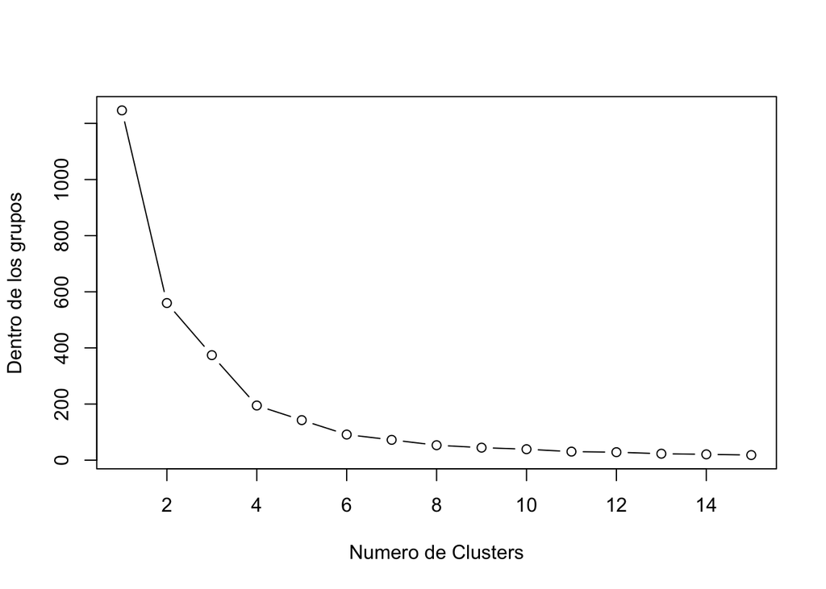

```r
jambu(moon)
```

Como se observa, la curva comienza a perder pronunciacion con 4 clusters

## kmeans en moon.csv

```r
moon.kmeans <- kmeans(moon, centers = 4)
MCk <- table(true = moon$V3, pred = moon.kmeans$cluster)
MCk
```

```
##     pred
## true   1   2   3   4
##    1   0 246   0 254
##    2 251   0 249   0
```

## Clasificacion jerarquica en moon.csv

### Metodo single

```r
moon.single <- hclust(dist(as.matrix(moon)), method = "single")
corte.moon.single <- cutree(moon.single, k = 4)
MCs <- table(true = moon$V3, pred = corte.moon.single)
MCs
```

```
##     pred
## true   1   2   3   4
##    1 499   0   0   1
##    2   0 498   2   0
```

### Metodo Complete

```r
moon.complete <- hclust(dist(as.matrix(moon)), method = "complete")
corte.moon.complete <- cutree(moon.complete, k = 4)
MCc <- table(true = moon$V3, pred = corte.moon.complete)
MCc
```

```
##     pred
## true   1   2   3   4
##    1 217 283   0   0
##    2 155   0 197 148
```

### Metodo Average

```r
moon.average <- hclust(dist(as.matrix(moon)), method = "average")
corte.moon.average <- cutree(moon.average, k = 4)
MCa <- table( true = moon$V3, pred = corte.moon.average)
```

# Conclusion

Dependiendo de el dataset aportado para el analisis, existen distintos tipos de algoritmos que se pueden comportar de manera mas eficiente tanto a nivel de computo como a nivel de analisis visual.

Por ende es importante saber que es lo que se desea obtener, para asi, filtrar los datos. y manejarlos de tal manera de encontrar la respuesta que se desea y asi poder hacerlo de la manera mas eficiente posible.